# Exercise - ggplot2

> Run following command in R console to link to `ggplot2` library:

```r
library(ggplot2)
```

> Load data if you have not done so yet:

```r
dt_KPI <- read.csv("./Data/lesson2_KPI.csv")
```

[output not shown]

### First Plot - Scatter

> Now let’s try to show our data on simple scatter plot

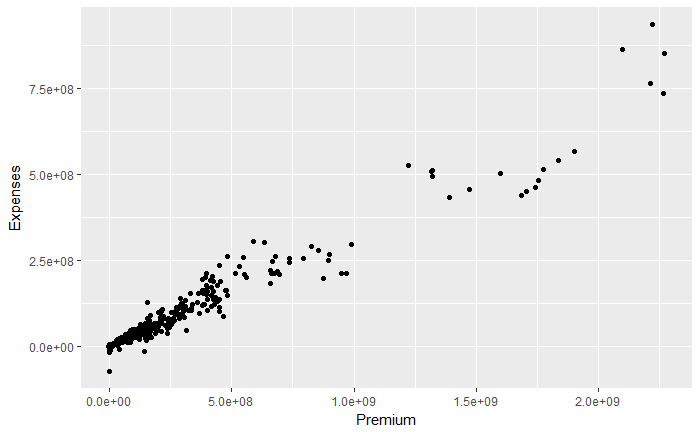

```r
ggplot(data = dt_KPI, aes(x = Premium, y = Expenses)) + geom_point()
```

> We used `ggplot` function specifying *data* set to use, `aes` function to specify *aestetics* (visualisation) and *geoms* function `geom_point` to specify how data should be represemeted.  
> Note that `+` serves as sign to add geom layer to a chart. We will use this technique in future steps as well.

### Aesthetics and layers

> In previous example we set *data* and *aesthetics* on global level, setting axes in *geoms* to *Premium* and *Expenses*. We will do the same now but specifying it for geom `geom_points` only. This is usefull when you want to show multiple measures on same chart having their own axes.  
> In addition we will also specify colour of dots varying colour by *Region*.

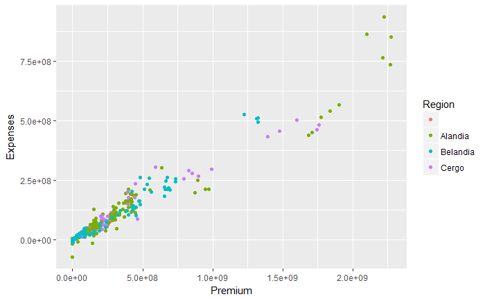

```r
ggplot(data = dt_KPI) +
  geom_point(mapping = aes(x = Premium, y = Expenses, colour = Region))
```

### Geometric Objects and iheritance of aesthetics

> Now let’s add new *geom* for smoothed regresion line. We will do so by adding new *geom* using `+` sign and function `geom_smooth`.

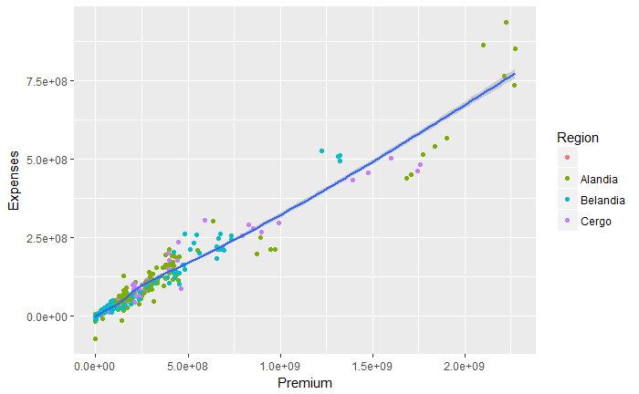

```r
ggplot(data = dt_KPI) +
  geom_point(mapping = aes(x = Premium, y = Expenses, colour = Region)) +
  geom_smooth(mapping = aes(x = Premium, y = Expenses))
```

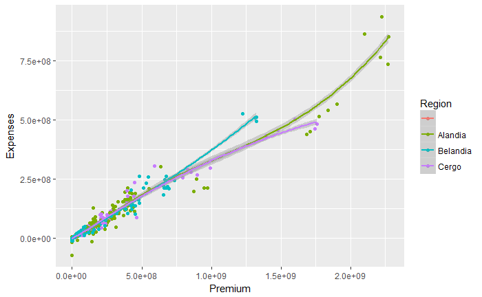

```r
ggplot(data = dt_KPI, mapping = aes(x = Premium, y = Expenses, colour = Region)) +
  geom_point() +
  geom_smooth()
```

> It produced chart with dots and smoothed line where regresion is done on data by *Region*.  
> This feature of `ggplot` is called *inheritance*. You can do lot’s using it.

> Visit https://github.com/rstudio/cheatsheets/raw/master/data-visualization-2.1.pdf for more information about ggplot2